# Case Salario Candidato

Marcio Cruz

28/06/2021

## Case

Um recrutador deseja estimar o salário de um candidato, a partir da nota média de várias provas realizadas durante o processo seletivo de admissão na empresa. O objetivo é ajudar os gestores a atribuir o salário do candidato dentro do intervalo já estipulado pela política de remuneração da empresa.

### Hipóteses para β1:

#### Ho: β1 = 0 (não existe relação linear entre as variáveis)

#### Ha: β1 # 0 (existe relação linear entre as variáveis)

### Hipóteses para β0:

#### Ho: β0 = 0 (Passa pela origem)

#### Ha: β0 # 0 (Não passa pela origem)

## Respostas

### a) Obtenha o gráfico de dispersão entre as variáveis

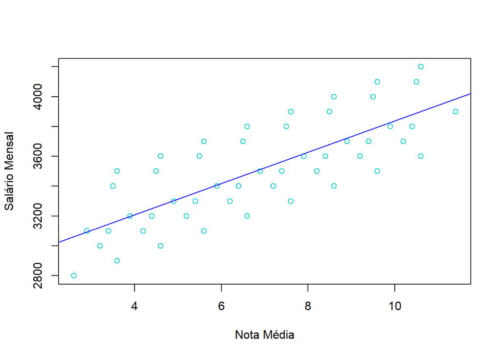

### b) Calcule o coeficiente de correlação entre as variáveis. É uma correlação positiva ou negativa? É uma correlação forte?

**Interpretação:** Existe uma correlação forte e positiva (r = 0.7765) entre as variáveis de salário e nota média.

### c) Obtenha o modelo de regressão linear simples. Com 90% de confiança, há relação linear entre as variáveis?

```r
regressao <- lm(data=salario, salario$`Salario Mensal` ~ salario$`Nota Média`)
# summary(regressao)
```

#### O pvalor (0.0000000000344) < 0,10 indica que devemos rejeitar a hipótese nula, ou seja, aceitar que existe relação linear entre as variáveis.

### d) Interprete os parâmetros do modelo e o coeficiente de determinação.

#### Se um determinado funcionário tiver hipoteticamente nota 0, seu salário será de R$ 2.788,88

### e) Apresente a equação do modelo estimada.

y_estimado <- 2788.88 + 104.04 * x

### f) Estime o valor do salário para um candidato que possui a nota média igual a 7

O valor estimado do salário para quem tirou nota 7 na prova é R$ 3517.16